# Comparing analytic and numeric results

gustav

Mon Dec 18 16:38:20 2017

```r
library(mizer)
```

We want to investigate how well the mizer numerics can reproduce the analytic solution that we can obtain in the case of non-interacting species.

## Without density dependence

### Set parameters

```r
f0 <- 0.6
alpha <- 0.4
r_pp <- 10^18  # Choosing a high value because we want the plankton to stay
               # at its power-law steady state
n <- 2/3
p <- n
q <- 0.95
lambda <- 2+q-n
erepro <- 0.1
R <- 1e10  # The rate of reproduction

beta <- 100
sigma <- 1.3
h <- 30
ks <- 4
kappa <- 1e8

w_min <- 1e-2
w_inf <- 1e3
w_mat <- 10^2.4  # About 251, a quarter of w_inf
min_w_pp <- 1e-7  # Only have to make sure the smallest fish are perfectly fed
# Chose number of gridpoints so that w_mat and w_inf lie on gridpoints
no_w <- log10(w_inf/w_min)*10+1

species_params <- data.frame(
  species = "Single",
  w_min = w_min,
  w_inf = w_inf,
  w_mat = w_mat,
  h = h,
  ks = ks,
  beta = beta,
  sigma = sigma,
  z0 = 0,
  alpha = alpha,
  erepro = erepro,
  sel_func = "knife_edge", # not used but required
  knife_edge_size = 1000
)

params <- MizerParams(species_params, p=p, n=n, q=q, lambda = lambda, f0 = f0,
                      kappa = kappa, min_w = w_min, max_w = w_inf, no_w = no_w,
                      min_w_pp = min_w_pp, w_pp_cutoff = w_inf, r_pp = r_pp)
```

```
## Note:    No gamma column in species data frame so using f0, h, beta, sigma, lambda and kappa to calculate it.
```

```r
gamma <- params@species_params$gamma[1]
w <- params@w
```

### Exact solution

We set the background death to $\mu_0 w^{n-1}$ and choose
$$\mu_0 = (1-f_0) \sqrt{2\pi} \kappa \gamma \sigma
\beta^{n-1} \exp(\sigma^2 (n-1)^2 / 2)$$
which is the death rate that is produced by predation if the predators follow the same power law as the plankton. We could equally well have chosen any other constant for $\mu_0$.

```r
mu0 <- (1-f0) * sqrt(2*pi) * kappa * gamma * sigma *
  (beta^(n-1)) * exp(sigma^2 * (n-1)^2 / 2)
params@mu_b[1, ] <- mu0 * w^(n-1)
```

The rate at which energy is available for growth and reproduction is $\bar{h} w^n$, with $\bar{h} = \alpha h f_0 - k_s$.

```r
hbar <- alpha * h * f0 - ks
```

n_exact is calculated using the analytic expression for the solution,
$$N(w) = \frac{R}{\bar{h} w^n} (w_0/w)^{\mu_0/\bar{h}}
\times \begin{cases} 1 & w<w_{mat}\\
\left(1-(w/W_{inf})^{1-n}\right)^{\mu_0/\bar{h}/(1-n)-1}
\left(1-(w_{mat}/W_{inf})^{1-n}\right)^{-\mu_0/\bar{h}/(1-n)} & w>w_{mat}
\end{cases}$$

```r
pow <- mu0/hbar/(1-n)
n_mult <- (1 - (w/w_inf)^(1-n))^(pow-1) * (1 - (w_mat/w_inf)^(1-n))^(-pow)
n_mult[w < w_mat] <- 1
n_exact <- params@psi  # Just to get array with correct dimensions and names
n_exact[] <- R * (w_min/w)^(mu0/hbar) / (hbar * w^n) * n_mult
```

### Mizer setup for non-interacting scenario

Make sure that the rate of reproduction is R

```r
params@srr <- function(rdi, species_params) {return(species_params$R)}
params@species_params$R <- R
```

We use a step function for the maturity function

```r
params@psi[1, ] <- (w/w_inf)^(1-n)
params@psi[1, w < w_mat] <- 0
params@psi[1, w > w_inf] <- 1
```

We switch off the self-interaction

```r
params@interaction[] <- 0
```

We start the simulation with the exact steady-state solution

```r
sim <- project(params, t_max=50, effort = 0, initial_n = n_exact)
```

### Comparison of solutions

If all is well, it should stay close to the steady-state solution.

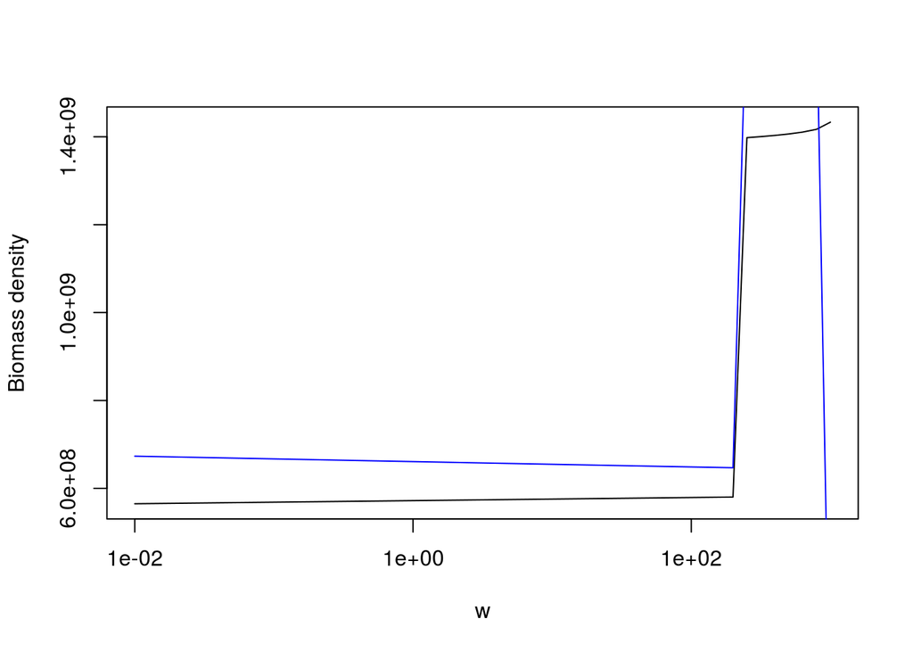

```r
plot(w, sim@n[dim(sim@n)[1],1,]*w, log="x", type="l", ylab="Biomass density")
lines(w, n_exact[1,]*w, col="blue")
```

There is a sizeable relative error at small sizes. Also the numerics are off substantially at the maximum size. We plot the relative error but exclude that maximum size.

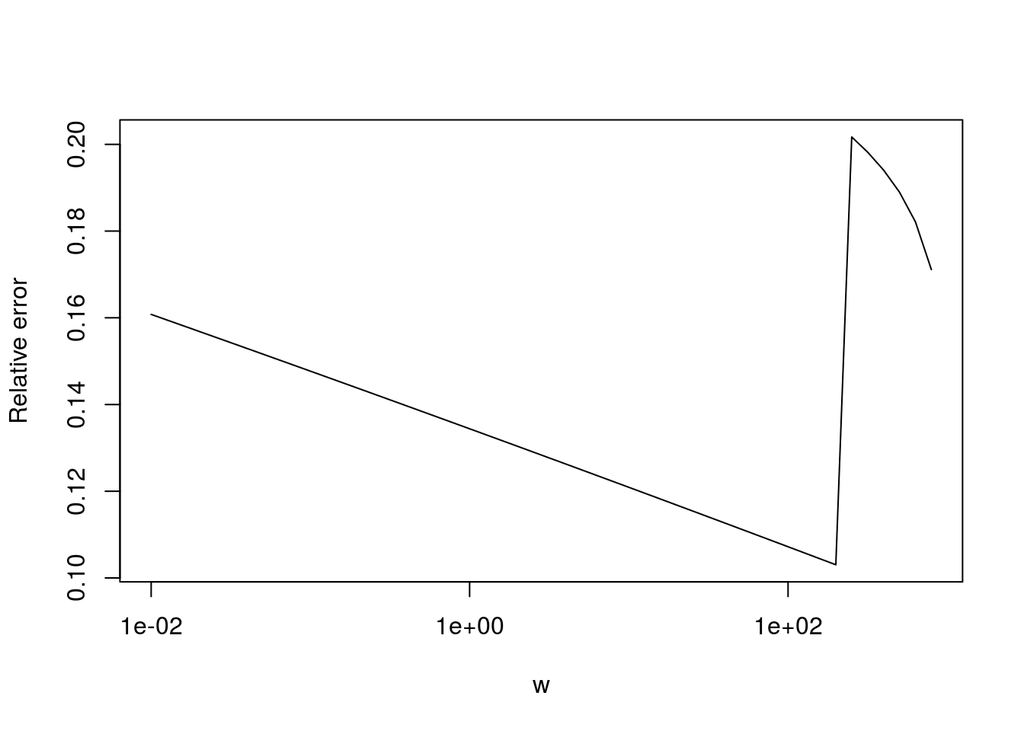

```r
relative_error <- (n_exact[1,]-sim@n[dim(sim@n)[1],1,])/n_exact[1,]
plot(w[1:(no_w-1)], relative_error[1:(no_w-1)], type="l", log="x",
     xlab="w", ylab="Relative error")
```

Let’s us increase the number of steps by a factor of 10

```r
no_w <- log10(w_inf/w_min)*100+1
params <- MizerParams(species_params, p=p, n=n, q=q, lambda = lambda, f0 = f0,
                      kappa = kappa, min_w = w_min, max_w = w_inf, no_w = no_w,
                      min_w_pp = min_w_pp, w_pp_cutoff = w_inf, r_pp = r_pp)
```

```
## Note:    No gamma column in species data frame so using f0, h, beta, sigma, lambda and kappa to calculate it.
```

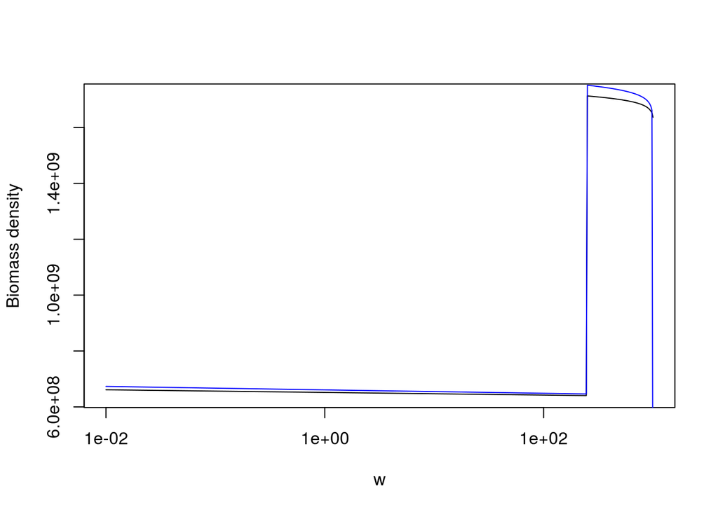

```r
# New grid, so we need to recalculate various things
w <- params@w
params@mu_b[1, ] <- mu0 * w^(n-1)
params@srr <- function(rdi, species_params) {return(species_params$R)}
params@species_params$R <- R
params@psi[1, ] <- (w/w_inf)^(1-n)
params@psi[1, w < w_mat] <- 0
params@psi[1, w > w_inf] <- 1
params@interaction[] <- 0
n_mult <- (1 - (w/w_inf)^(1-n))^(pow-1) * (1 - (w_mat/w_inf)^(1-n))^(-pow)
n_mult[w < w_mat] <- 1
n_exact <- params@psi
n_exact[] <- R * (w_min/w)^(mu0/hbar) / (hbar * w^n) * n_mult
sim <- project(params, t_max=50, effort = 0, initial_n = n_exact)
plot(w, sim@n[dim(sim@n)[1],1,]*w, log="x", type="l", ylab="Biomass density")
lines(w, n_exact[1,]*w, col="blue")
```

Now the agreement is much better

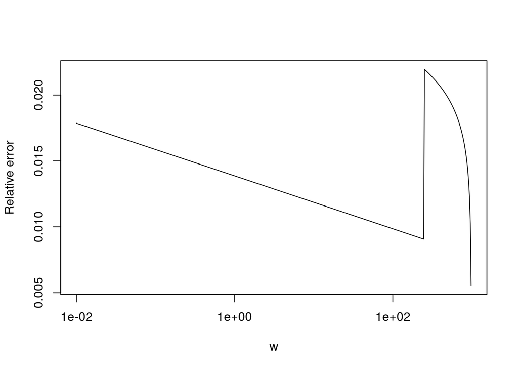

```r
relative_error <- (n_exact[1,]-sim@n[dim(sim@n)[1],1,])/n_exact[1,]
plot(w[1:(no_w-1)], relative_error[1:(no_w-1)], type="l", log="x",
     xlab="w", ylab="Relative error")
```

We see that the error has also gone down by a factor of 10. So the numerical method appears to be first-order in stepsize. It will be worthwhile to think about how to improve this.

## With density dependence

Now we repeat the same calculation with the same parameters, except that we turn on density dependence

```r
chi <- 0.05
params@chi_b <- chi
```

Now there is no elementary analytic solution for the abundance of mature fish (the solution involves a hypergeometric function), but for juvenile fish we have
$$N(w) = \frac{1}{\bar{h}w^n} \left(
R^{-\chi} - \frac{\mu_0}{n \bar{h}^{\chi+1}} (w^{-n\chi}-w_0^{-n\chi})
\right)^{-1/\chi}$$

```r
n_exact[] <- 1/(hbar * w^n) * (
        R^(-chi) - mu0/(n*hbar^(chi+1)) * (w^(-n*chi)-w_min^(-n*chi))
      )^(-1/chi)
```

We run the simulation and compare the results (in black) to the above exact solution (in blue)

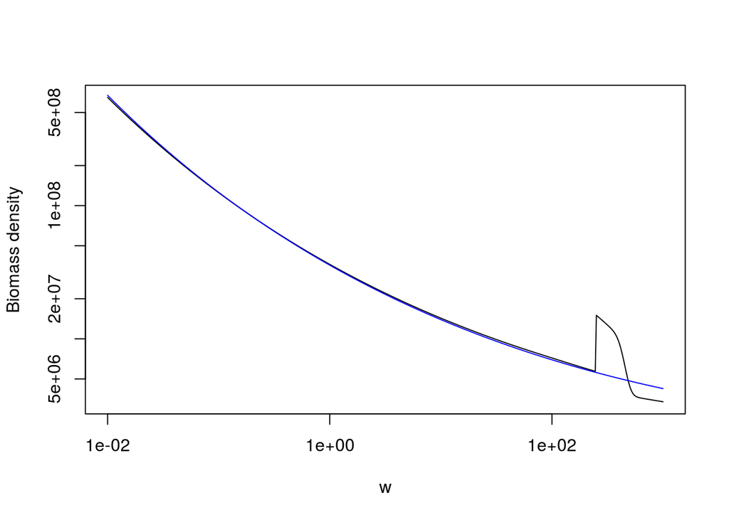

```r
sim <- project(params, t_max=5, effort = 0, initial_n = n_exact)
plot(w, sim@n[dim(sim@n)[1],1,]*w, log="xy", type="l", ylab="Biomass density")
lines(w, n_exact[1,]*w, col="blue")
```

Note that we used a logarithmic scale also on the y axis because now the biomass is no longer approximately constant for juveniles but changes over several orders of magnitude.

It is clear from the shape of the mature spectrum that the system has not yet had time to reach steady-state. So we run it for longer.

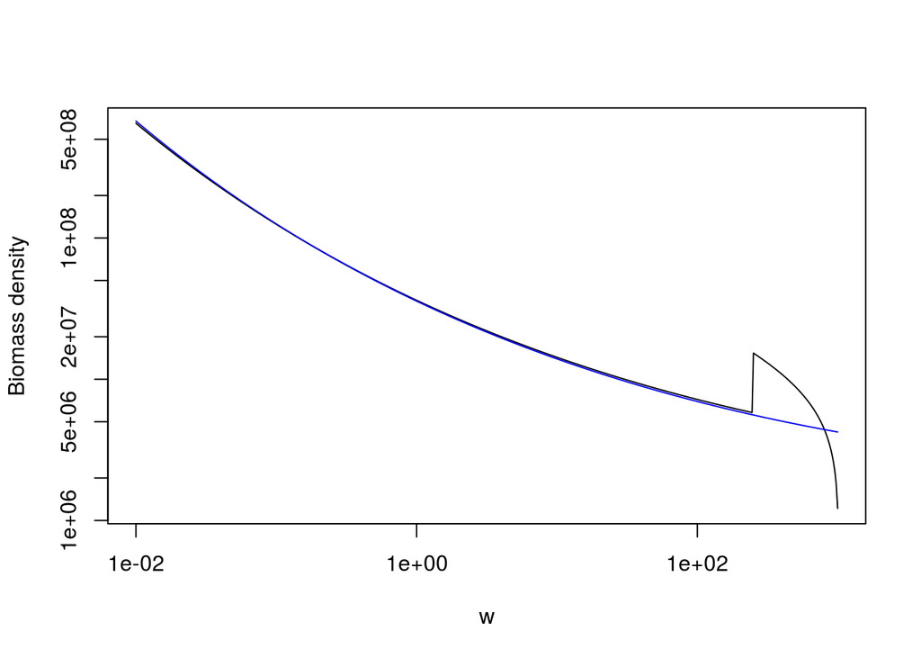

```r
sim <- project(params, t_max=50, effort = 0, initial_n = n_exact)
plot(w, sim@n[dim(sim@n)[1],1,]*w, log="xy", type="l", ylab="Biomass density")
lines(w, n_exact[1,]*w, col="blue")
```

We plot the relative error in the juvenile region

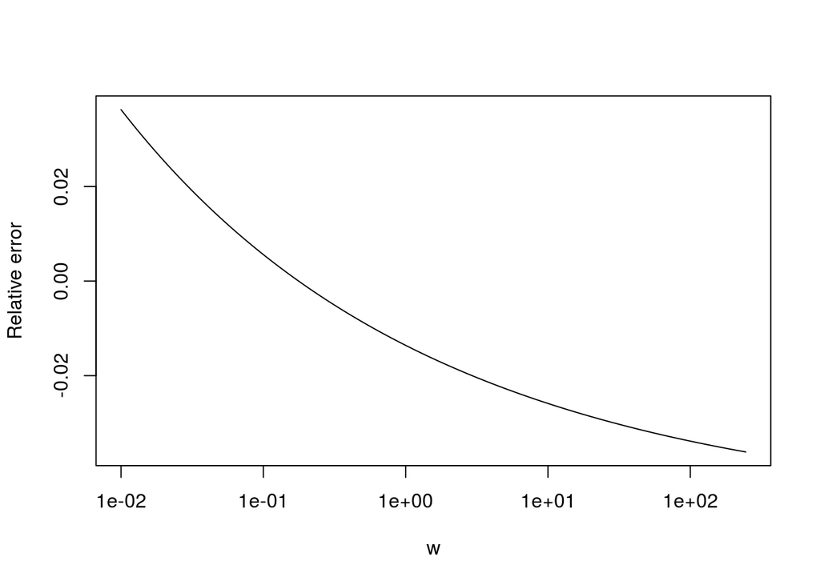

```r
relative_error <- (n_exact[1,]-sim@n[dim(sim@n)[1],1,])/n_exact[1,]
plot(w[w<w_mat], relative_error[w<w_mat], type="l", log="x",
     xlab="w", ylab="Relative error")
```

The number of eggs produced is close to the number of eggs R used.

```r
rdi <- getRDI(params, matrix(sim@n[dim(sim@n)[1], , ], nrow = 1), params@cc_pp)[1,1]
rdi/R
```

```
##   Single
## 0.902655
```

Let us see what happens when we take away the restriction to the number of eggs and instead use all eggs.

```r
params@srr <- function(rdi, species_params) {return(rdi)}
sim <- project(params, t_max=200, effort = 0, initial_n = n_exact)
```

We use the biomass plot to judge whether steady-state has been reached

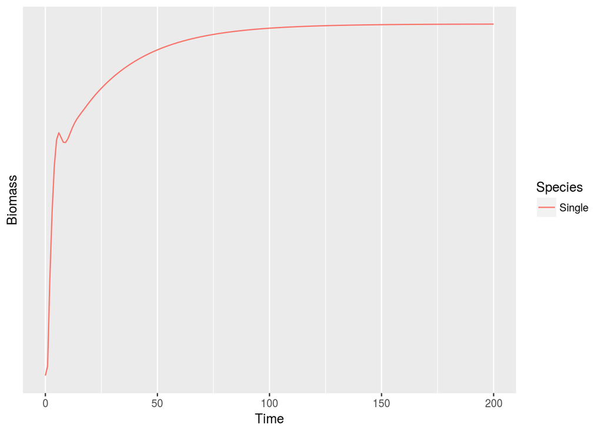

```r
plotBiomass(sim, print_it=FALSE)
```

This has settled down nicely.

We plot the solution (in black) together with the analytic juvenile solution appropriate for the new rate of egg production

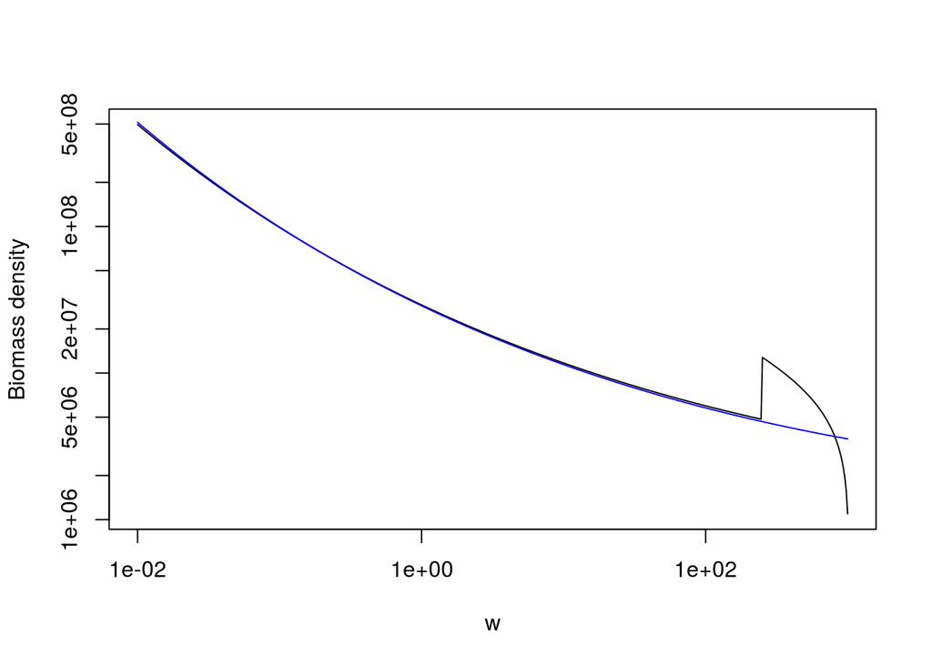

```r
rdi <- getRDI(params, matrix(sim@n[dim(sim@n)[1], , ], nrow = 1), params@cc_pp)[1,1]
n_exact[] <- 1/(hbar * w^n) * (
  rdi^(-chi) - mu0/(n*hbar^(chi+1)) * (w^(-n*chi)-w_min^(-n*chi))
    )^(-1/chi)
plot(w, sim@n[dim(sim@n)[1],1,]*w, log="xy", type="l", ylab="Biomass density")
lines(w, n_exact[1,]*w, col="blue")
```

## Putting several species together

We’ll use our solution from above as a template

```r
n_init <- sim@n[dim(sim@n)[1],1,]
```

We set up 11 species with egg size between $10^-4$ and $10^-2$, equally spaced in log space

```r
dist_sp <- 0.2
no_sp <- 2/dist_sp + 1
species <- 1:no_sp
x_min <- seq(-4, by = dist_sp, length.out = no_sp)
w_min <- 10^x_min
w_inf <- 10^(x_min+5)
w_mat <- 10^(x_min+4.4)  # This is about a quarter of w_inf
min_w <- min(w_min)
max_w <- max(w_inf)
no_w <- log10(max_w/min_w)*100+1
min_w_pp <- 1e-8

species_params <- data.frame(
  species = 1:no_sp,
  w_min = w_min,
  w_inf = w_inf,
  w_mat = w_mat,
  h = h,
  ks = ks,
  beta = beta,
  sigma = sigma,
  z0 = 0,
  alpha = alpha,
  gamma = gamma,
  erepro = erepro,
  sel_func = "knife_edge", # not used but required
  knife_edge_size = 1000
)

params <- MizerParams(species_params, p=p, n=n, q=q, lambda = lambda, f0 = f0,
                      kappa = kappa, min_w = min_w, max_w = max_w, no_w = no_w,
                      min_w_pp = min_w_pp, w_pp_cutoff = max_w, r_pp = r_pp,
                      chi_b = chi)

w <- params@w
params@srr <- function(rdi, species_params) {return(rdi)}
params@interaction[] <- 0
initial_n <- params@psi
for (i in 1:no_sp) {
  initial_n[i, params@species_params$w_min_idx[i]:(params@species_params$w_min_idx[i]+length(n_init)-1)] <-
    n_init * (w_min[no_sp]/w_min[i])^lambda
  params@psi[i, ] <- (w/w_inf[i])^(1-n)
  params@psi[i, w < w_mat[i]] <- 0
  params@psi[i, w > w_inf[i]] <- 1
  params@mu_b[i, ] <- mu0 * w^(n-1) * (w_min[no_sp]/w_min[i])^(-chi*lambda)
}
sim <- project(params, t_max=50 ,effort = 0, initial_n = initial_n)
```

We plot the species biomass over time to see that we are in the steady state.

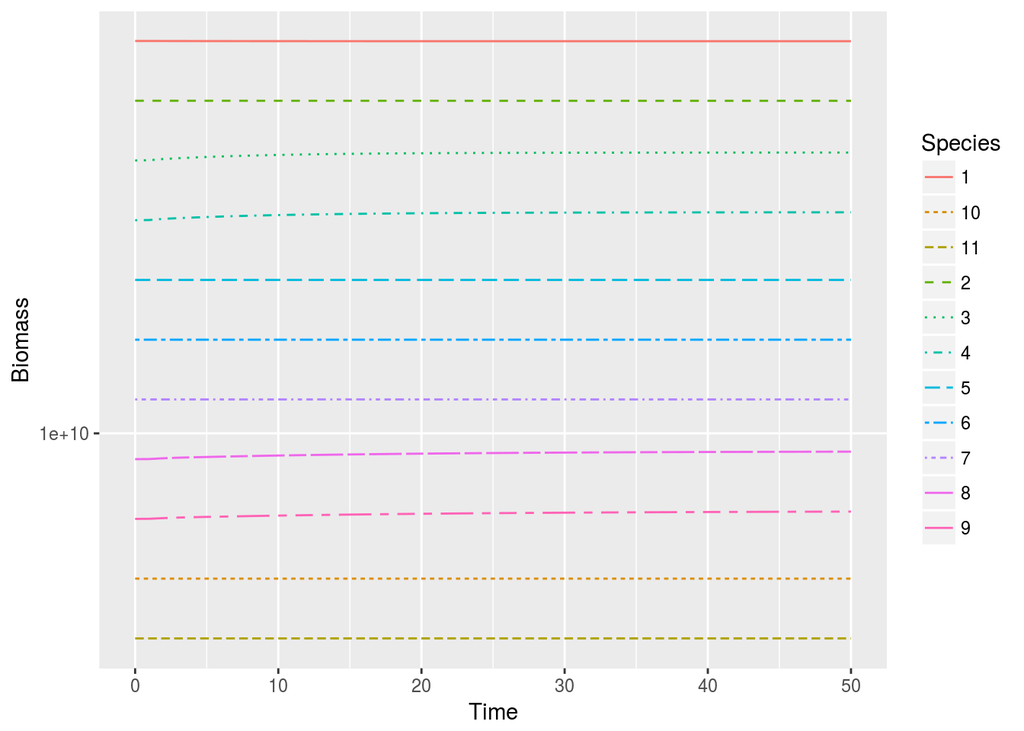

[figure not shown]

```r
plotBiomass(sim)
```

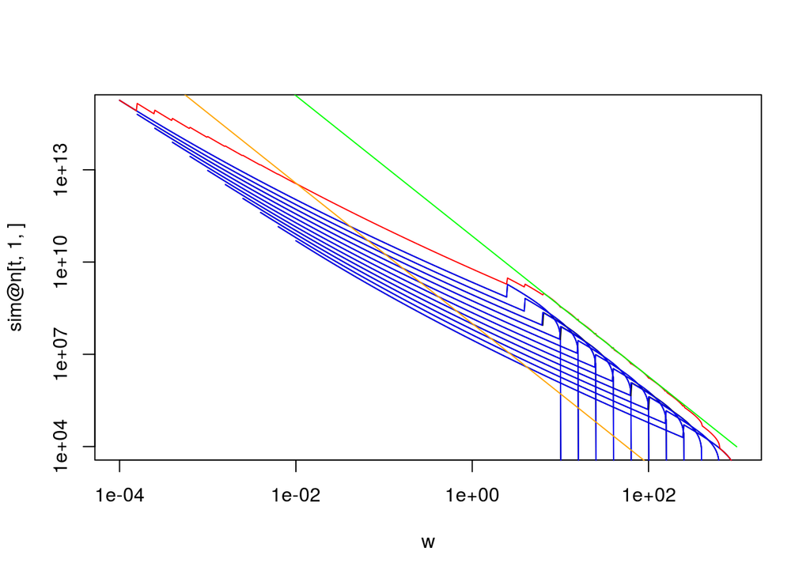

```r
t <- dim(sim@n)[1]
plot(w, sim@n[t,1,], log="xy", type="l", ylim=c(10^(4),10^(15)))
lines(w, sim@n[1,1,], col="blue")
for (i in 2:no_sp){
  lines(w, sim@n[t,i,])
  lines(w, sim@n[1,i,], col="blue")
}
lines(w, colSums(sim@n[t,,]), col="red")
lines(w, kappa*w^(-lambda), col="orange")
lines(w, 7e10*w^(-lambda), col="green")
```

We overlay on that plot the community spectrum (in red), the background spectrum (in orange). This shows that the community is too high compared to the background.